# Basic testing of nonlinear model approach for total biomass

Alice Stears

2025-08-29

Set user defined parameters

```r
coverType <- params$coverType
ecoregion <- params$ecoregion

# print
print(paste0("For this model run, the ecoregion is ", ecoregion," and the cover type used as a predictor is ", coverType,"."))
```

```
## [1] "For this model run, the ecoregion is dryShrubGrass and the cover type used as a predictor is C3GramCover."
```

Load packages and data

```r
# load packages -----------------------------------------------------------
library(tidyverse)
library(gnm)
library(terra)
library(tidyterra)
library(patchwork)
library(sf)
# load data ---------------------------------------------------------------

dat <- readRDS("/Users/astears/Documents/Dropbox_static/Work/NAU_USGS_postdoc/PED_vegClimModels/Data_processed/BiomassQuantityData/dataForAnalysis_fireAndDevelopmentRemoved.rds")

# get only total biomass from GEDI
dat <- dat %>%
  filter(biomassSource == "GEDI") %>%
  sf::st_drop_geometry()

# make min. biomass value not 0
dat[dat$biomass_MgPerHect == 0 & !is.na(dat$biomass_MgPerHect), "biomass_MgPerHect"] <-
  dat[dat$biomass_MgPerHect == 0 & !is.na(dat$biomass_MgPerHect), "biomass_MgPerHect"] + .001

# # try transforming the model response
#  dat[, "totalBiomass_MgHect"] + 2

# scale the predictors
name_lookup <- c(
  tmean_s = "tmean",
  prcpTempCorr_s = "prcpTempCorr",
  isothermality_s = "isothermality",
  annWatDef_s ="annWatDef",
  prcp_s = "prcp",
  prcp_seasonality_s = "prcp_seasonality",
  prcp_dry_s = "prcp_dry",
  annWetDegDays_s = "annWetDegDays",
  t_warm_s = "t_warm",
  t_cold_s = "t_cold",
  prcp_wet_s = "prcp_wet",
  soilDepth_s = "soilDepth",
  sand_s = "sand",
  coarse_s = "coarse",
  AWHC_s = "AWHC",
  clay_s = "clay",
  carbon_s = "carbon")

dat_scaled <- dat %>%
  select(tmean, prcpTempCorr, isothermality, annWatDef,
         prcp, prcp_seasonality, prcp_dry, annWetDegDays,
         t_warm, t_cold, prcp_wet, soilDepth, sand, coarse, AWHC, clay, carbon) %>%
  dplyr::rename(all_of(name_lookup)) %>%
  scale()

dat <- dat %>%
  cbind(dat_scaled) %>%
  #select(1:40,43:65) %>%
  mutate(totalTreeCover = broadLeavedTreeCover + needleLeavedTreeCover, # calculate total tree and herbaceous cover
         totalHerbaceousCover = C3GramCover + C4GramCover + forbCover)

## fix issue with forest ecoregion naming
levels(dat$newRegion) <- c(levels(dat$newRegion), "forest")
dat[dat$newRegion %in% c("eastForest", "westForest"), "newRegion"] <- "forest"
```

Look at input data for climate and soils predictors

```r
scaleFigDat_1 <- dat %>%
  dplyr::select(c(#Long, Lat, Year,
    Long, Lat, tmean, prcpTempCorr, isothermality, annWatDef,
         prcp, prcp_seasonality, prcp_dry, annWetDegDays,
         t_warm, t_cold, prcp_wet, soilDepth, sand, coarse, AWHC, clay, carbon)) %>%
  pivot_longer(cols = c(tmean, prcpTempCorr, isothermality, annWatDef,
         prcp, prcp_seasonality, prcp_dry, annWetDegDays,
         t_warm, t_cold, prcp_wet, soilDepth, sand, coarse, AWHC, clay, carbon),
               names_to = "predNames",
               values_to = "predValues_unScaled")
scaleFigDat_2 <- dat %>%
  dplyr::select(c(#Long, Lat, Year,
    Long, Lat, tmean_s:carbon_s)) %>%
  pivot_longer(cols = c(tmean_s:carbon_s),
               names_to = "predNames",
               values_to = "predValues_scaled",
               names_sep = ) %>%
  mutate(predNames = str_replace(predNames, pattern = "_s$", replacement = ""))

scaleFigDat_3 <- scaleFigDat_1 %>%
  left_join(scaleFigDat_2)
```

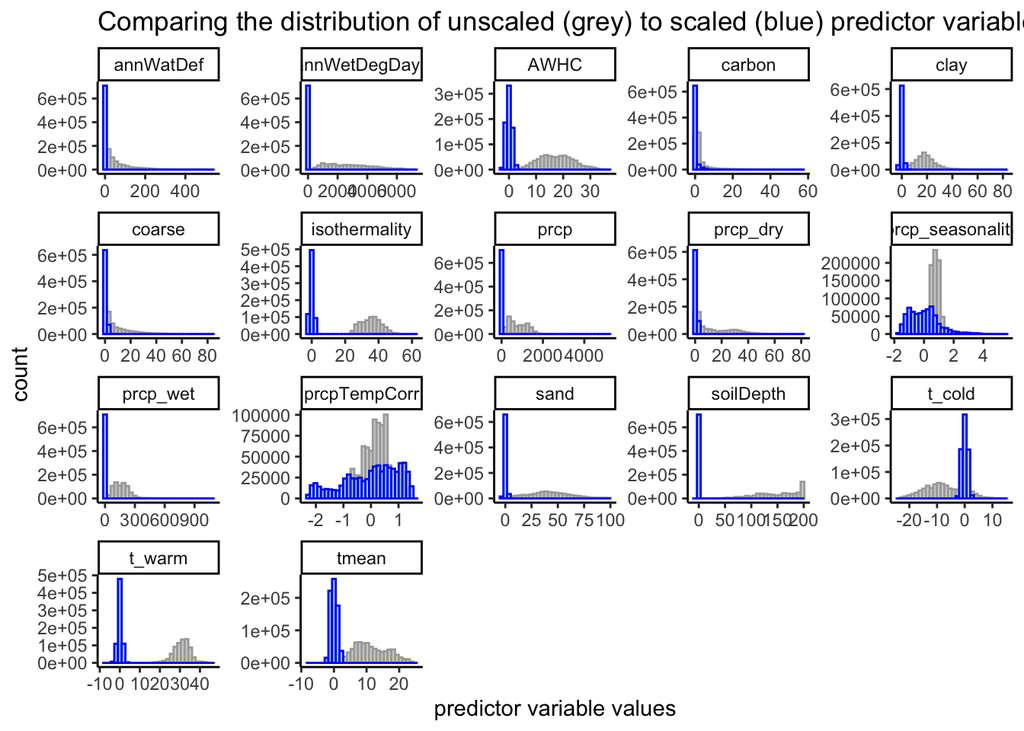

```r
ggplot(scaleFigDat_3) +
  facet_wrap(~predNames, scales = "free") +
  geom_histogram(aes(predValues_unScaled), fill = "lightgrey", col = "darkgrey") +
  geom_histogram(aes(predValues_scaled), fill = "lightblue", col = "blue") +
  xlab ("predictor variable values") +
  ggtitle("Comparing the distribution of unscaled (grey) to scaled (blue) predictor variables") +
  theme_classic()
```

(From Daniel): ” What we ultimately want from these models is information about this relationship like this: $biomass(type_i, pixel_j) \sim predictors_{ij}$

However, we don’t have $biomass(type_i, .)$; we do have $totalBiomass$ and $cover(type_i, .)$. Even though the relationship between cover and biomass is not ideal at high cover value as we have discussed a little while ago, it may be what is available to us. This would look like: $biomass(type_i, pixel_j) \sim biomassTotal(pixel_j) * allometricFraction(type_i, cover_i)$

Instead of scouring the literature for such biomass ~ cover relationships for each of our 6 types, how would it work if we fit that relationship in the same model fitting as biomass ~ predictors? Along the lines of: $biomassTotal(pixel_j) * allometricFraction(type_i, cover_i) \sim predictors_{ij}$

We probably want a saturating relationship for allometricFraction(), potentially as simple as $allometricFraction(type_i, cover) \sim(( b + 100) * ( cover + 1))/( 100 * ( b + cover + 1)$

Potentially, we could consider separate relationships for the non-tree types in the presence of trees (or simply in our “forest” ecoregion) to separate out understory conditions from “real” grasslands/shrublands. ”

Rewritten, this equation is $biomassTotal(pixel_j) \sim predictors_{ij} *(100 * ( b^2 + cover + 1) / (( b^2 + 100) * ( cover + 1)))$

```r
# specify model with gnm --------------------------------------------------
#μ=(β 1⋅climate+β2⋅soils)⋅f(cover;β3,β4)
# Here, climate and soils have linear effects (beta1, beta2) while beta3, beta4 are estimated through Nonlin().
dat_cover <- dat %>%
   filter(newRegion %in% #c("eastForest", "westForest")) %>%
            c(ecoregion)) %>%
  select(biomass_MgPerHect, all_of(coverType), tmean_s, prcpTempCorr_s, isothermality_s, annWatDef_s,
         prcp_s, prcp_seasonality_s, prcp_dry_s, annWetDegDays_s,
         t_warm_s, t_cold_s, prcp_wet_s, soilDepth_s, sand_s, coarse_s,
         AWHC_s, clay_s, carbon_s, Long, Lat, newRegion, tmean, prcpTempCorr, isothermality, annWatDef,
         prcp, prcp_seasonality, prcp_dry, annWetDegDays,
         t_warm, t_cold, prcp_wet, soilDepth, sand, coarse, AWHC, clay, carbon) %>%
 drop_na() #%>%
 #  mutate(carbon_s = log(carbon_s + 20),
 #         coarse_s = log(coarse_s + 20),
 #         prcp_dry_s = log(prcp_dry_s + 20),
 #         prcp_wet_s = log(prcp_wet_s + 20))

# make sure that shrub cover is > 0
dat_cover[dat_cover[,coverType]==0, coverType]
```

```
## numeric(0)
```

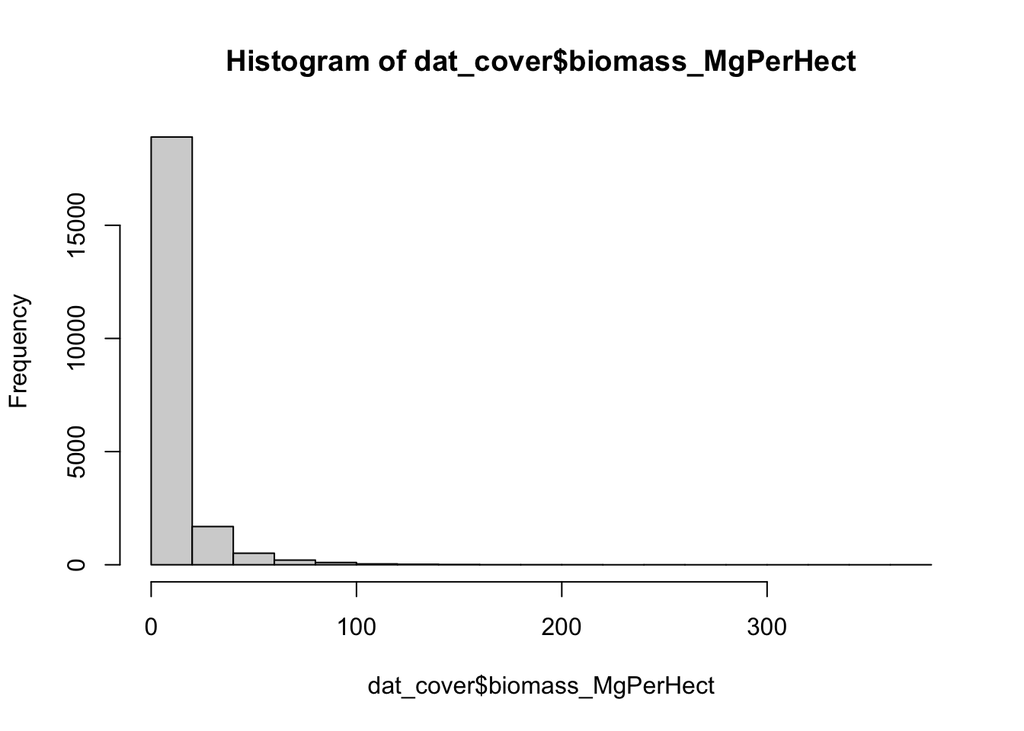

```r
# do a log transformation of the response
# dat_cover <- dat_cover %>%
#   mutate(biomass_MgPerHect_logPlusConstant = log(biomass_MgPerHect + 4))

# use a transformation of total biomass so the gamma model will fit
dat_cover[, "biomass_MgPerHect"] <- dat_cover[, "biomass_MgPerHect"] + 2

hist(dat_cover$biomass_MgPerHect)
```

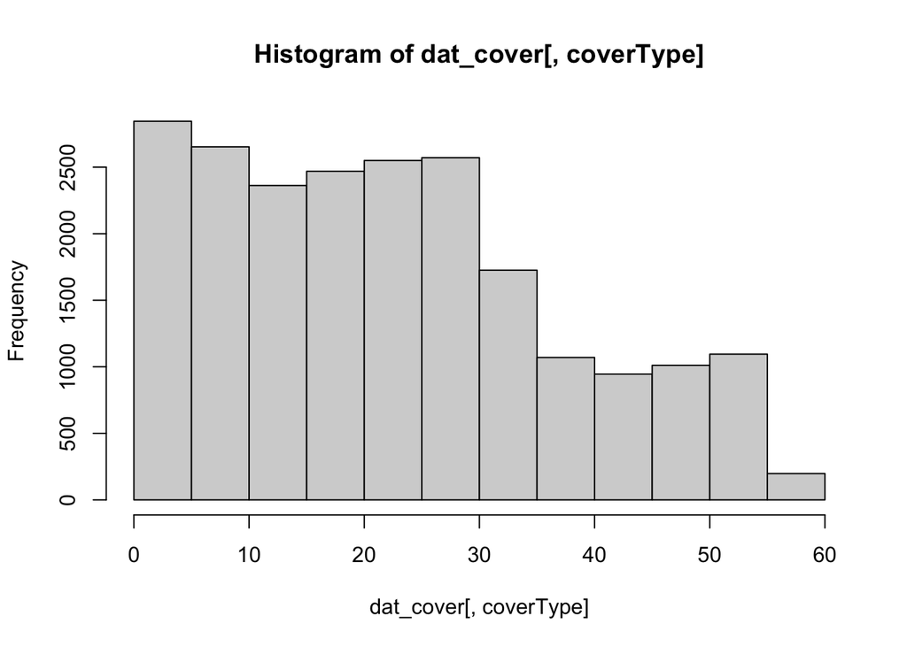

```r
hist(dat_cover[,coverType])
```

```r
#define custom function for allometric term
# invAF <- function(x) {
#   list(
#     predictors = list(bCover = 1),
#     variables = list(substitute(x)),
#     term = function(predLabels, varLabels) {
#       paste(
#         "100 * (", predLabels[1], "+", varLabels[1], " + 1) / ((",
#         predLabels[1], "+ 100) * (", varLabels[1], " + 1))"
#       )
#     },
#     start = function(beta) {
#       beta[1] <- 1
#       beta
#     }
#   )
# }
#
# class(invAF) <- "nonlin"

invAF2 <- function(x) {
  list(
    predictors = list(bCover = 1),
    variables = list(substitute(x)),
    term = function(predLabels, varLabels) {
      paste(
        "100 * (", predLabels[1], "^2 +", varLabels[1], " + 1) / ((",
        predLabels[1], "^2 + 100) * (", varLabels[1], " + 1))"
      )
    },
    start = function(beta) {
      beta[1] <- 1
      beta
    }
  )
}

class(invAF2) <- "nonlin"

# rename cover variable of interest for ease with the model calls
dat_cover <- dat_cover %>%
rename("coverOfInterest" = all_of(coverType))

## use glm to get starting values for the gnm
glm_fit <- glm(biomass_MgPerHect ~ tmean_s + prcpTempCorr_s +  isothermality_s + annWatDef_s + prcp_s +
                 prcp_seasonality_s + prcp_dry_s + annWetDegDays_s + t_warm_s + t_cold_s + prcp_wet_s + soilDepth_s +
                 sand_s + coarse_s + AWHC_s + clay_s + carbon_s + offset(100 * (1 + coverOfInterest + 1)/((1 + 100) * (coverOfInterest + 1))),

                   #(1 + 100)*needleLeavedTreeCover*(1/(100*(1+needleLeavedTreeCover))))   ,
               # 1/(1 + exp(- needleLeavedTreeCover)))
               data = dat_cover,
               family = Gamma(link = "log"))
# Then use coef(glm_fit) to initialize beta_j (for the linear terms) in your gnm start vector.

## re-write the nonlinear term (1/(1 + exp(-x))) to be exp(x)/1+exp(x) so that the model actually fits
#debug(gnm:::gnmFit)
fit_gnm <- gnm(biomass_MgPerHect ~ gnm::Mult(tmean_s + prcpTempCorr_s +  isothermality_s + annWatDef_s +
                                                 prcp_s + prcp_seasonality_s + prcp_dry_s + annWetDegDays_s +
                                                 t_warm_s + t_cold_s + prcp_wet_s + soilDepth_s + sand_s +
                                                 coarse_s + AWHC_s + clay_s + carbon_s, invAF2(coverOfInterest)),
               #1 + offset(needleLeavedTreeCover), gnm::Inv(needleLeavedTreeCover + offset(100 * needleLeavedTreeCover))
               #(1 + 100), needleLeavedTreeCover, gnm::Inv(gnm::Mult(100, (1 + offset(needleLeavedTreeCover))))
               #gnm::Inv(needleLeavedTreeCover), (1 + offset(needleLeavedTreeCover))
               method =  "gnmFit", #"coefNames",
               start =  #rep(1, length.out = 19),
                 c(coef(glm_fit)[1:18], 1),
               data = dat_cover,
               family = Gamma(link = "log"),
               iterMax = 10000,
               trace = TRUE, #TRUE,
               verbose = TRUE#TRUE
)
```

```
## Initial Deviance = 67063.614184
## Running main iterations
## Iteration 1. Deviance = 25580.571485
## Iteration 2. Deviance = 11778.050471
## Iteration 3. Deviance = 9420.540405
## Iteration 4. Deviance = 9310.905857
## Iteration 5. Deviance = 9309.718209
## Iteration 6. Deviance = 9309.690435
## Iteration 7. Deviance = 9309.689131
## Iteration 8. Deviance = 9309.689011
## Iteration 9. Deviance = 9309.688994
## Iteration 10. Deviance = 9309.688991
## Iteration 11. Deviance = 9309.688990
## Iteration 12. Deviance = 9309.688990
## Iteration 13. Deviance = 9309.688990
## Iteration 14. Deviance = 9309.688990
## Iteration 15. Deviance = 9309.688990
## Iteration 16. Deviance = 9309.688990
## Iteration 17. Deviance = 9309.688990
## Done
```

See how the allometric fraction term looks with fitted coefficients (the actual allometric fraction, not the inverse allometric fraction)

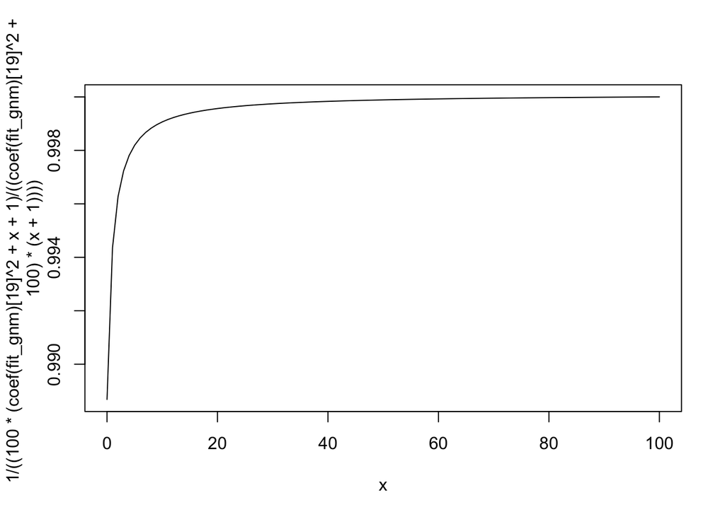

```r
curve(1/((100 * (coef(fit_gnm)[19]^2 + x + 1) / ((coef(fit_gnm)[19]^2 + 100) *  (x + 1)))),

  #coef(fit_gnm)[19]*1/(1+exp(-x)),#(.99 * x) / (coef(fit_gnm)[20] + x),
  from = 0, to = 100)
```

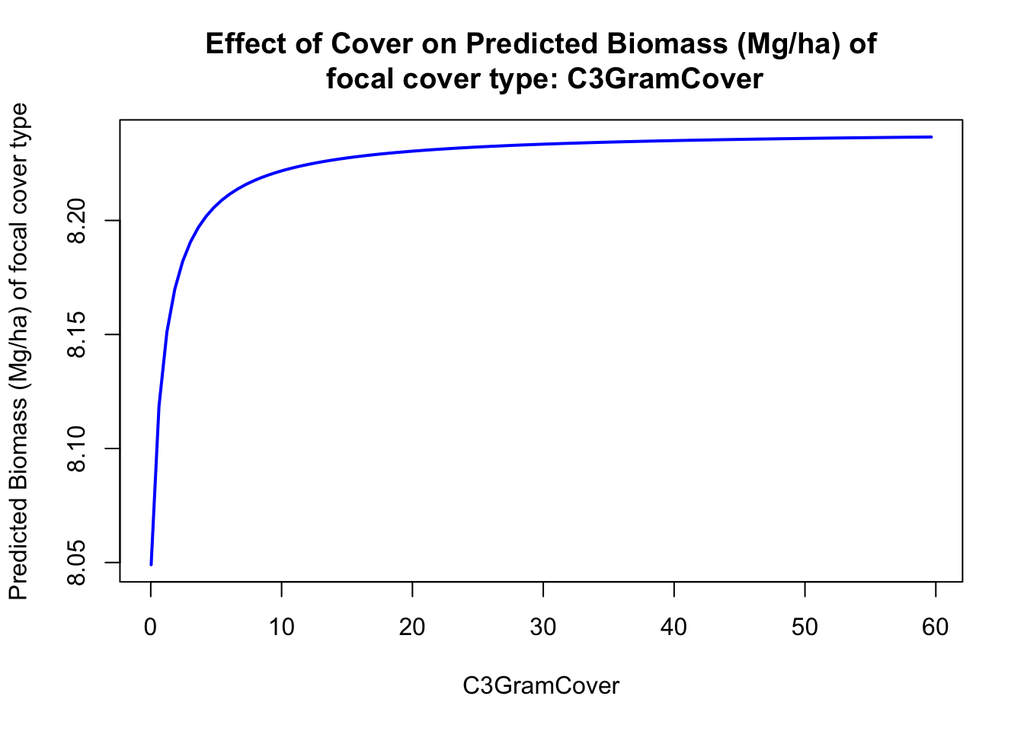

```r
# Predict using this model ------------------------------------------------
# Generate a sequence of cover values across observed range
cover_seq <- seq(min(dat_cover$coverOfInterest, na.rm = TRUE),
                 max(dat_cover$coverOfInterest, na.rm = TRUE),
                 length.out = 100)

# Create a new data frame for prediction
new_data <- data.frame(
  coverOfInterest = cover_seq,
  #coverOfInterest_transformed = exp(cover_seq),
  tmean_s = mean(dat_cover$tmean_s, na.rm = TRUE),
  prcpTempCorr_s = mean(dat_cover$prcpTempCorr_s, na.rm = TRUE),
  isothermality_s = mean(dat_cover$isothermality_s, na.rm = TRUE),
  annWatDef_s = mean(dat_cover$annWatDef_s, na.rm = TRUE),
  prcp_s = mean(dat_cover$prcp_s, na.rm = TRUE),
  prcp_seasonality_s = mean(dat_cover$prcp_seasonality_s, na.rm = TRUE),
  prcp_dry_s = mean(dat_cover$prcp_dry_s, na.rm = TRUE),
  annWetDegDays_s = mean(dat_cover$annWetDegDays_s, na.rm = TRUE),
  t_warm_s = mean(dat_cover$t_warm_s, na.rm = TRUE),
  t_cold_s = mean(dat_cover$t_cold_s, na.rm = TRUE),
  prcp_wet_s = mean(dat_cover$prcp_wet_s, na.rm = TRUE),
  soilDepth_s= mean(dat_cover$soilDepth_s, na.rm = TRUE),
  sand_s = mean(dat_cover$sand_s, na.rm = TRUE),
  coarse_s = mean(dat_cover$coarse_s, na.rm = TRUE),
  AWHC_s = mean(dat_cover$AWHC_s, na.rm = TRUE),
  clay_s = mean(dat_cover$clay_s, na.rm = TRUE),
  carbon_s = mean(dat_cover$carbon_s, na.rm = TRUE)
)

# Predict biomass on the response scale
new_data$predicted_biomass <- predict(fit_gnm, newdata = new_data, type = "response") #- 2

# predict biomass of focal cover type
new_data$predicted_biomass_FOCALcoverType <- new_data$predicted_biomass * ((coef(fit_gnm)[19]^2+ 100) *  (new_data$coverOfInterest + 1))/(100 * (coef(fit_gnm)[19]^2 + (new_data$coverOfInterest + 1)))


# 5. Plot the predictions
plot(
  new_data$coverOfInterest,
  new_data$predicted_biomass_FOCALcoverType,
  type = "l",
  lwd = 2,
  col = "blue",
  xlab = coverType,
  ylab = "Predicted Biomass (Mg/ha) of focal cover type",
  main = paste0("Effect of Cover on Predicted Biomass (Mg/ha) of\n focal cover type: ", coverType)
)
```

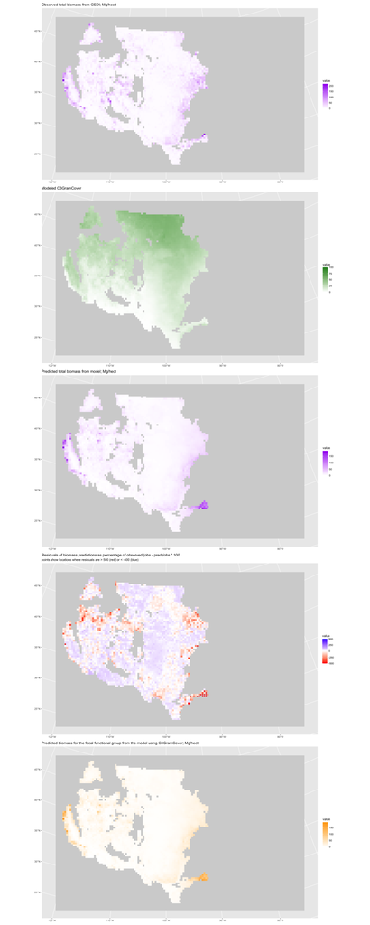

```r
# plot the predictions and residuals --------------------------------------
# rasterize the biomass and shrub cover data
test_rast <-  rast("/Users/astears/Documents/Dropbox_static/Work/NAU_USGS_postdoc/PED_vegClimModels/Data_raw/dayMet/rawMonthlyData/orders/70e0da02b9d2d6e8faa8c97d211f3546/Daymet_Monthly_V4R1/data/daymet_v4_prcp_monttl_na_1980.tif")
# rasterize total biomass in Mg/hect
dat_biomass_rast <- dat_cover %>%
  terra::vect(geom = c("Long", "Lat"), crs = crs(test_rast)) %>%
  terra::rasterize(test_rast, field = "biomass_MgPerHect") %>%
  terra::aggregate(fun = "mean", na.rm = TRUE, fact = 32)
# rasterize % shrub cover
dat_cover_rast <- dat_cover %>%
  terra::vect(geom = c("Long", "Lat"), crs = crs(test_rast)) %>%
  terra::rasterize(test_rast, field = "coverOfInterest") %>%
  terra::aggregate(fun = "mean", na.rm = TRUE, fact =32)

# generate predictions for this model using training data
# the 'shrub cover' term is called "coverOfInterest_term" in the dat_cover data.frame
# Predict biomass on the response scale
dat_cover$predicted_totalBiomass <- predict(fit_gnm, newdata = dat_cover, type = "response") - 2
# rasterize predicted total biomass in Mg/hect
dat_biomassPreds_rast <- dat_cover %>%
  terra::vect(geom = c("Long", "Lat"), crs = crs(test_rast)) %>%
  terra::rasterize(test_rast, field = "predicted_totalBiomass") %>%
  terra::aggregate(fun = "mean", na.rm = TRUE, fact = 32) %>%
  terra::crop(y = dat_biomass_rast)

## calculate the residuals
dat_resids_rast <- (dat_biomass_rast - dat_biomassPreds_rast)/dat_biomass_rast * 100

## calculate the model predicted biomass for the target functional group
dat_funcGroupBiomassPred <- dat_biomassPreds_rast * ((coef(fit_gnm)[19]^2+ 100) *  (dat_cover_rast + 1))/(100 * (coef(fit_gnm)[19]^2 + (dat_cover_rast + 1)))

#dat_biomassPreds_rast *coef(fit_gnm)[19]*1/(1+exp(-dat_cover_rast)) #(.99 * dat_cover_rast) / (coef(fit_gnm)[20] + dat_cover_rast)

# make plots
plot_biomass <- ggplot() +
  geom_spatraster(data = dat_biomass_rast) +
  #geom_point(data = dat_cover[badLines,], aes(x = Long, y = Lat)) +
  labs(title = paste0("Observed total biomass from GEDI; Mg/hect")) +
  scale_fill_gradient2(low = "white",
                       high = "purple" ,
                       limits = c(0,max(terra::values(dat_biomass_rast, na.rm = TRUE))),  na.value = "lightgrey") +
  xlim(c(-2060750, 2555250)) +
  ylim(c(-1895500, 972500))

dat_biomassPreds_big <- dat_biomassPreds_rast %>%
  terra::mask(mask = ifel(. > 1500, 1, NA)) %>%
  terra::as.points()

plot_biomassPreds <- ggplot() +
    geom_spatraster(data = dat_biomassPreds_rast) +
  geom_spatvector(data = dat_biomassPreds_big, col = "darkorchid") +
    labs(title = paste0("Predicted total biomass from model; Mg/hect"),
         subtite = "Points indicate locations where predicted biomass is > 2000") +
    scale_fill_gradient2(low = "white",
                         high = "purple" ,
                         limits = c(0, max(terra::values(dat_biomassPreds_rast, na.rm = TRUE))),  na.value = "lightgrey") +
    xlim(c(-2060750, 2555250)) +
    ylim(c(-1895500, 972500))

# points where values are >500 or < -500
dat_resids_big <- dat_resids_rast %>%
  terra::mask(mask = ifel(. > 500, 1, NA)) %>%
  terra::as.points()
dat_resids_small <- dat_resids_rast %>%
  terra::mask(mask = ifel(. < -500, 1, NA)) %>%
  terra::as.points()
plot_biomassResids <- ggplot() +
    geom_spatraster(data = dat_resids_rast) +
    geom_spatvector(data = dat_resids_big, col = "blue") +
    geom_spatvector(data = dat_resids_small, col = "red") +
    labs(title = paste0("Residuals of biomass predictions as percentage of observed (obs - pred)/obs * 100"),
         subtitle = "points show locations where residuals are > 500 (red) or < -500 (blue)") +
    scale_fill_gradient2(low = "red",
                         high = "blue" ,
                         limits = c(-500,500),  na.value = "lightgrey") +
    xlim(c(-2060750, 2555250)) +
    ylim(c(-1895500, 972500))

# plot of herbaceous cover
plot_coverOfInterest <- ggplot() +
    geom_spatraster(data = dat_cover_rast) +
  #geom_point(data = dat_cover[badLines,], aes(x = Long, y = Lat)) +
    labs(title = paste0("Modeled ", coverType)) +
    scale_fill_gradient2(low = "white",
                         high = "forestgreen" ,
                         limits = c(0,100),  na.value = "lightgrey") +
    xlim(c(-2060750, 2555250)) +
    ylim(c(-1895500, 972500))

# plot of target functional group biomass
plot_funcGroupBiomassPred <- ggplot() +
    geom_spatraster(data = dat_funcGroupBiomassPred) +
    labs(title = paste0("Predicted biomass for the focal functional group from the model using ", coverType, "; Mg/hect"),
         subtite = "Points indicate locations where predicted biomass is > 2000") +
    scale_fill_gradient2(low = "white",
                         high = "orange" ,
                         #limits = c(0,2000),
                         na.value = "lightgrey") +
    xlim(c(-2060750, 2555250)) +
    ylim(c(-1895500, 972500))

# # make plot w/ RAP data for total herbaceous
# RAPdat <- terra::rast("/Users/astears/Documents/Dropbox_static/Work/NAU_USGS_postdoc/PED_vegClimModels/Data_processed/BiomassQuantityData/RAP_biomassRaster_totalHerb_Mg_Hect_averagedfrom2019to2021.tif")
# RAPdat <- RAPdat %>%
#   terra::resample(y = dat_funcGroupBiomassPred)

# # plot
# plot_RAPbiomass <- ggplot() +
#     geom_spatraster(data = RAPdat) +
#     labs(title = paste0("Herbaceous biomass from RAP; Mg/hect")) +
#     scale_fill_gradient2(low = "white",
#                          high = "orange" ,
#                          #limits = c(0,2000),
#                          na.value = "lightgrey") +
#     xlim(c(-2060750, 2555250)) +
#     ylim(c(-1895500, 972500))
#
# # plot resids between model predictions and RAP
# dat_residsFromRap_rast <- (RAPdat - dat_funcGroupBiomassPred)/RAPdat * 100

# points where values are >500 or < -500
# dat_residsFromRap_big <- dat_residsFromRap_rast %>%
#   terra::mask(mask = ifel(. > 500, 1, NA)) %>%
#   terra::as.points()
# dat_residsFromRap_small <- dat_residsFromRap_rast %>%
#   terra::mask(mask = ifel(. < -500, 1, NA)) %>%
#   terra::as.points()
# plot_biomassResidsFromRap <- ggplot() +
#     geom_spatraster(data = dat_residsFromRap_rast) +
#     geom_spatvector(data = dat_residsFromRap_big, col = "red") +
#     geom_spatvector(data = dat_residsFromRap_small, col = "blue") +
#     labs(title = paste0("Residuals of biomass predictions as percentage of observed (obs - pred)/obs * 100"),
#          subtitle = "points show locations where residuals are > 500 (red) or < -500 (blue)") +
#     scale_fill_gradient2(low = "blue",
#                          high = "red" ,
#                          limits = c(-500,500),  na.value = "lightgrey") +
#     xlim(c(-2060750, 2555250)) +
#     ylim(c(-1895500, 972500))

(plot_biomass ) /  plot_coverOfInterest/ (plot_biomassPreds )/plot_biomassResids/plot_funcGroupBiomassPred #/ plot_RAPbiomass / #lot_biomassResidsFromRap
```

Notes for future attempts… try a tensor product smooth in a gam? gam4 package (isntead of mgcv) is better for non-Gaussian models

```r
# # biomass density plot
# ggplot(data = dat_cover) +
#   geom_density(aes(biomass_MgPerHect)) +
#   #geom_vline(data = dat_cover[badLines,], aes(xintercept = biomass_MgPerHect), col = "orange") +
#   geom_density(data = dat_cover[badLines,], aes(biomass_MgPerHect), col = "orange") +
#   theme_classic()
# # cover density plot
# ggplot(data = dat_cover) +
#   geom_density(aes(coverOfInterest)) +
#   #geom_vline(data = dat_cover[badLines,], aes(xintercept = coverOfInterest), col = "orange") +
#   geom_density(data = dat_cover[badLines,], aes(coverOfInterest), col = "orange") +
#   theme_classic()
#
#
# # predictor density plots
# lapply(names(dat_tree)[3:16], FUN = function(name_i) {
#   plot_i <- ggplot(data = dat_tree) +
#   geom_density(aes(.data[[name_i]])) +
#   #geom_vline(data = dat_tree[badLines,], aes(xintercept = .data[[name_i]]), col = "orange") +
#   geom_density(data = dat_tree[badLines,], aes(.data[[name_i]]), col = "orange") +
#   ggtitle(paste(name_i)) +
#   theme_classic()
#   assign(paste0(name_i,"_densityFig"), plot_i, envir = .GlobalEnv)
# })
# library(patchwork)
# get(paste0(names(dat_tree)[3], "_densityFig")) + get(paste0(names(dat_tree)[4], "_densityFig")) +
# get(paste0(names(dat_tree)[5], "_densityFig")) + get(paste0(names(dat_tree)[6], "_densityFig")) +
# get(paste0(names(dat_tree)[7], "_densityFig")) + get(paste0(names(dat_tree)[8], "_densityFig")) +
# get(paste0(names(dat_tree)[9], "_densityFig")) + get(paste0(names(dat_tree)[10], "_densityFig")) +
# get(paste0(names(dat_tree)[11], "_densityFig")) + get(paste0(names(dat_tree)[12], "_densityFig")) +
# get(paste0(names(dat_tree)[13], "_densityFig")) + get(paste0(names(dat_tree)[14], "_densityFig"))  +
# get(paste0(names(dat_tree)[15], "_densityFig")) + get(paste0(names(dat_tree)[16], "_densityFig"))
#
```